[figure not shown]

[figure not shown]

[figure not shown]

[figure not shown]

# **DATA 612 - Project 5 : Implementing a Recommender System on Spark**

### **Rupendra Shrestha, Bikash Bhowmik—- 06 Jul 2025**

Instruction  
Introduction  
Load Data  
Data preparation  
Recommender model  
Performance Comparison: recommenderlab vs Spark MLlib  
Conclusions

**Instruction**

The goal of this project is give you practice beginning to work with a distributedrecommender system. It is sufficient for this assignment to build out your application on a single node.Adapt one of your recommendation systems to work with Apache Spark and compare the performance with your previous iteration. Consider the efficiency of the system and the added complexity of using Spark. You may complete the assignment using PySpark (Python), SparkR (R) , sparklyr (R), or Scala. Please include in your conclusion: For your given recommender system’s data, algorithm(s), and (envisioned) implementation, at what point would you see moving to a distributed platform such as Spark becoming necessary?

**Introduction**

In recent years, recommender systems have become an important part of online platforms. They help users find movies, books, products, and other content based on their preferences. Traditional collaborative filtering methods work well with smaller datasets, but their effectiveness usually drops as the dataset grows. This is where distributed computing platforms like Apache Spark can help.

In this project, we expand the recommender system created in Project 4 by using a distributed environment with Apache Spark. We specifically employ Spark’s MLlib library and the `sparklyr` package in R to create a matrix factorization model with the Alternating Least Squares (ALS) algorithm.

The main goal of this project is to see how a distributed computing method can effectively scale collaborative filtering techniques for larger datasets. Although the MovieLens 100k dataset used here is relatively small, it serves as a useful test case for getting familiar with the Spark ecosystem. We will learn how to prepare data, build models, and evaluate performance using distributed methods.

We compare this Spark-based ALS model with earlier models in terms of how complex they are to implement, how well they perform, and how scalable they are. We also note potential benefits and drawbacks of using Spark and discuss when it’s necessary to transition from single-node to distributed environments.

**Load Data**

In this project, we use the MovieLens 100k dataset, which contains approximately 100,000 movie ratings from 943 users across 1,664 movies. Ratings range from 1 (worst) to 5 (best) and represent users’ preferences.

In this project, we explore the dataset using a distributed approach by leveraging the ALS matrix factorization method available in Spark’s MLlib, accessed through the sparklyr package running in local mode.

This setup allows us to explore the benefits of scalable recommendation techniques within a Spark-based environment.

**Data preparation**

We start by loading the data and preparing it for the recommender system. We see that the full ratings matrix includes over 99 thousand ratings, out of a total of 1.57 million user-movie pairs. This implies that the ratings matrix is 94% sparse.

```r
# load data
data("MovieLense")
m <- MovieLense

# examine the ratings matrix
head(colnames(m), 10)
```

```
 [1] "Toy Story (1995)"
 [2] "GoldenEye (1995)"
 [3] "Four Rooms (1995)"
 [4] "Get Shorty (1995)"
 [5] "Copycat (1995)"
 [6] "Shanghai Triad (Yao a yao yao dao waipo qiao) (1995)"
 [7] "Twelve Monkeys (1995)"
 [8] "Babe (1995)"
 [9] "Dead Man Walking (1995)"
[10] "Richard III (1995)"
```

```r
getRatingMatrix(m)[1:10, 1:30]
```

```
10 x 30 sparse Matrix of class "dgCMatrix"
```

```
1  5 3 4 3 3 5 4 1 5 3 2 5 5 5 5 5 3 4 5 4 1 4 4 3 4 3 2 4 1 3
2  4 . . . . . . . . 2 . . 4 4 . . . . 3 . . . . . 4 . . . . .
3  . . . . . . . . . . . . . . . . . . . . . . . . . . . . . .
4  . . . . . . . . . . 4 . . . . . . . . . . . . . . . . . . .
5  4 3 . . . . . . . . . . . . . . 4 . . . 3 . . 4 3 . . . 4 .
6  4 . . . . . 2 4 4 . . 4 2 5 3 . . . 4 . 3 3 4 . . . . 2 . .
7  . . . 5 . . 5 5 5 4 3 5 . . . . . . . . . 5 3 . 3 . 4 5 3 .
8  . . . . . . 3 . . . 3 . . . . . . . . . . 5 . . . . . . . .
9  . . . . . 5 4 . . . . . . . . . . . . . . . . . . . . . . .
10 4 . . 4 . . 4 . 4 . 4 5 3 . . 4 . . . . . 5 5 . . . . . . .
```

In order to use the ALS matrix factorization function in the Apache Spark MLlib package, we need to recast the ratings matrix into a dataframe with numeric (integer) values for user and item IDs. In the process we also save the actual movie names in case we need them later.

```r
# recast ratings matrix into dataframe with numeric user & item IDs
movie_names <- colnames(m)
colnames(m) <- 1:ncol(m)
df <- as(m, "data.frame")
df$user <- as.integer(df$user)
df$item <- as.integer(df$item)
df$rating <- as.integer(df$rating)
str(df)
```

```
'data.frame':   99392 obs. of  3 variables:
 $ user  : int  1 1 1 1 1 1 1 1 1 1 ...
 $ item  : int  1 2 3 4 5 6 7 8 9 10 ...
 $ rating: int  5 3 4 3 3 5 4 1 5 3 ...
```

```r
# view the dataframe
head(df)
```

```
    user item rating
1      1    1      5
453    1    2      3
584    1    3      4
674    1    4      3
883    1    5      3
969    1    6      5
```

```r
tail(df)
```

```
      user item rating
93643  943 1038      2
94227  943 1058      2
94450  943 1065      4
96451  943 1179      3
97147  943 1219      3
98112  943 1320      3
```

Next we establish a connection to Apache Spark in local mode, and copy the dataframe to a Spark table.

```r
# ---- spark_setup ----
# Set correct Spark version
# spark_home <- spark_install_find(version = "3.1.2", hadoop_version = "3.2")

# Manually set environment variable so sparklyr doesn't look for wrong one
# Sys.setenv(SPARK_HOME = spark_home)
# Sys.setenv(JAVA_HOME = "C:/Program Files/Java/jdk1.8.0_441")  # adjust as needed

# Ensure clean logging and connection
# options(sparklyr.log.console = TRUE)

# Connect to Spark using correct version and home
sc <- spark_connect(master = "local", version = "3.1.2")



ratings_tbl <- copy_to(sc, df, "ratings", overwrite = TRUE)
src_tbls(sc)
```

```
[1] "ratings"
```

```r
class(ratings_tbl)
```

```
[1] "tbl_spark" "tbl_sql"   "tbl_lazy"  "tbl"
```

```r
glimpse(ratings_tbl)
```

```
Rows: ??
Columns: 3
Database: spark_connection
$ user   <int> 1, 1, 1, 1, 1, 1, 1, 1, 1, 1, 1, 1, 1, 1, 1, 1, 1, 1, 1, 1, 1, …
$ item   <int> 1, 2, 3, 4, 5, 6, 7, 8, 9, 10, 11, 12, 13, 14, 15, 16, 17, 18, …
$ rating <int> 5, 3, 4, 3, 3, 5, 4, 1, 5, 3, 2, 5, 5, 5, 5, 5, 3, 4, 5, 4, 1, …
```

Next, we examine the ratings data by plotting the distribution of rating counts and average ratings, both per user and per movie. While this analysis generally runs smoothly in an R script, we encountered occasional stability issues when executing the same code within the RStudio Spark environment—specifically during collect() calls. These errors may stem from integration challenges between RStudio and Apache Spark. Despite this, the code reliably generates the intended histograms when run outside the notebook interface.

```r
# distribution of counts & avg rating per user
by_user <- ratings_tbl %>%
    group_by(user) %>%
    summarise(count = n(), avg = mean(rating, na.rm = TRUE)) %>%
    collect()
head(by_user)
```

```
# A tibble: 6 × 3
   user count   avg
  <int> <dbl> <dbl>
1    12    51  4.39
2    13   630  3.10
3    14    98  4.09
4    18   277  3.88
5    38   121  3.72
6    46    27  4.11
```

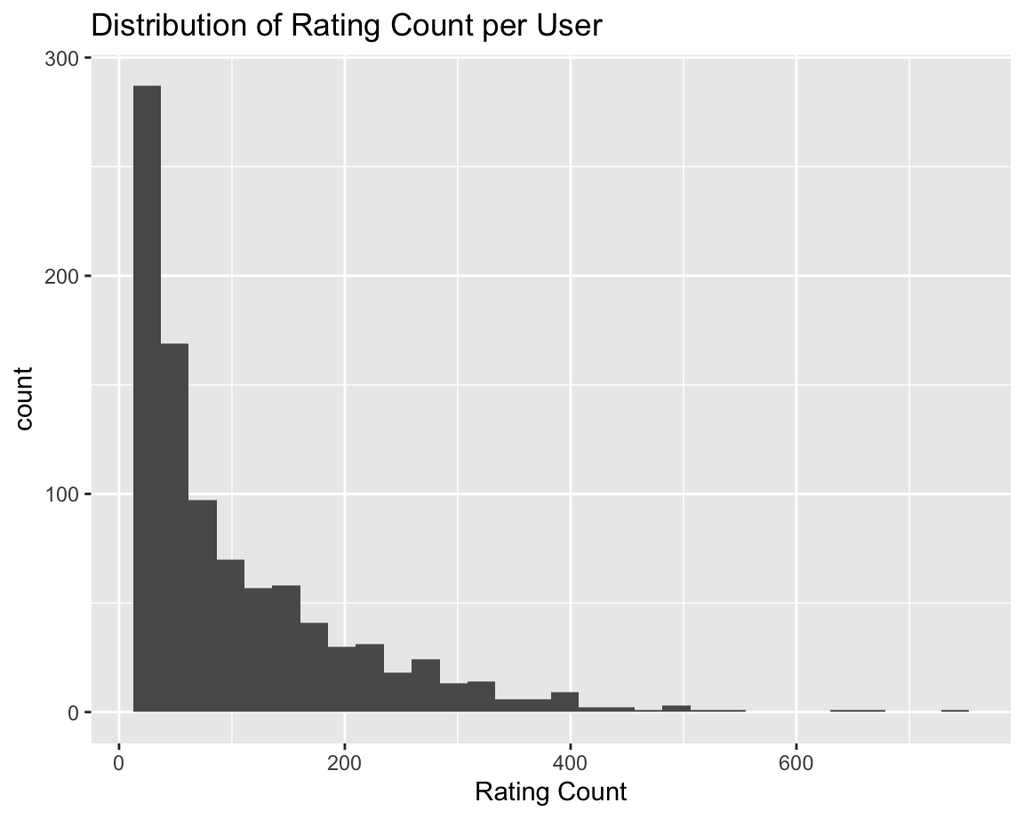

```r
ggplot(by_user, aes(count)) + geom_histogram() +
    labs(title = "Distribution of Rating Count per User",
         x = "Rating Count")
```

The histogram shows how many ratings each user provided. Most users rated only a small number of movies, while a few users rated many. This imbalance is typical in recommendation datasets and may affect model performance, as users with fewer ratings contribute less information to the learning process.

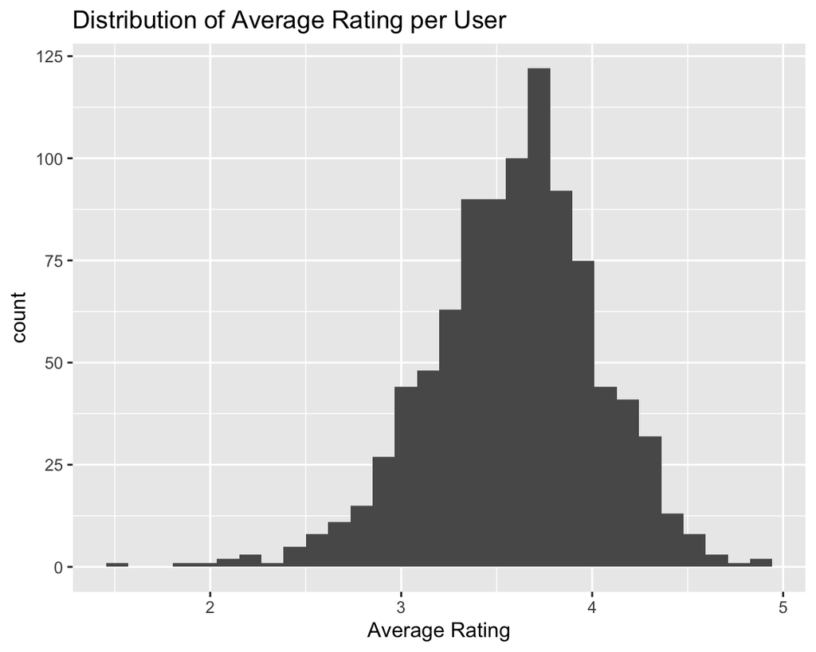

```r
ggplot(by_user, aes(avg)) + geom_histogram() +
    labs(title = "Distribution of Average Rating per User",
         x = "Average Rating")
```

The histogram displays the distribution of average ratings given by users. Most users tend to rate movies positively, with averages clustering around 3 to 4. This indicates a possible bias toward higher ratings, which is common in user-generated rating datasets.

```r
summary(by_user)
```

```
      user           count            avg
 Min.   :  1.0   Min.   : 19.0   Min.   :1.497
 1st Qu.:236.5   1st Qu.: 32.0   1st Qu.:3.325
 Median :472.0   Median : 64.0   Median :3.619
 Mean   :472.0   Mean   :105.4   Mean   :3.588
 3rd Qu.:707.5   3rd Qu.:147.5   3rd Qu.:3.871
 Max.   :943.0   Max.   :735.0   Max.   :4.870
```

```r
# distribution of counts & avg rating per movie
by_item <- ratings_tbl %>%
    group_by(item) %>%
    summarise(count = n(), avg = mean(rating, na.rm = TRUE)) %>%
    collect()
head(by_item)
```

```
# A tibble: 6 × 3
   item count   avg
  <int> <dbl> <dbl>
1    12   267  4.39
2    13   184  3.42
3    14   183  3.97
4    18    10  2.8
5    38   120  3.01
6    46    27  3.56
```

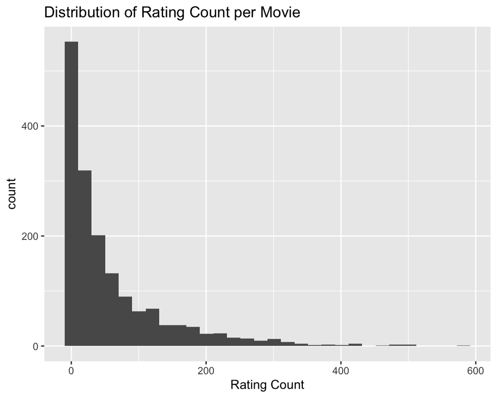

```r
par(mfrow = c(1,2))
ggplot(by_item, aes(count)) + geom_histogram() +
    labs(title = "Distribution of Rating Count per Movie",
         x = "Rating Count")
```

Most movies received relatively few ratings, while a small number were rated frequently. This long-tail distribution is common in recommendation datasets and highlights item popularity imbalance, which can affect recommendation diversity.

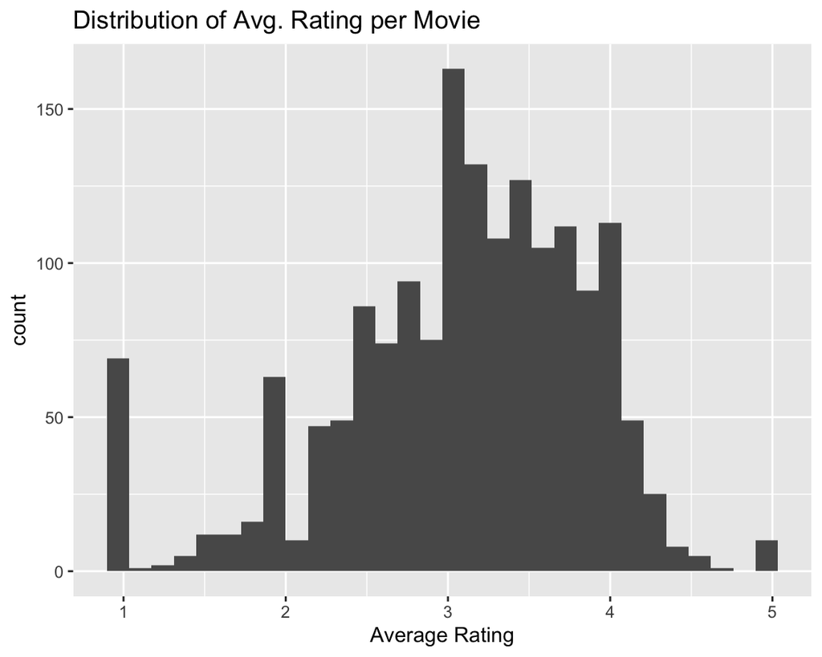

```r
ggplot(by_item, aes(avg)) + geom_histogram() +
    labs(title = "Distribution of Avg. Rating per Movie",
         x = "Average Rating")
```

```r
summary(by_item)
```

```
      item            count             avg
 Min.   :   1.0   Min.   :  1.00   Min.   :1.000
 1st Qu.: 416.8   1st Qu.:  7.00   1st Qu.:2.665
 Median : 832.5   Median : 27.00   Median :3.162
 Mean   : 832.5   Mean   : 59.73   Mean   :3.077
 3rd Qu.:1248.2   3rd Qu.: 80.00   3rd Qu.:3.653
 Max.   :1664.0   Max.   :583.00   Max.   :5.000
```

**Recommender model**

We will develop a recommender model based on the alternating least squares algorithm (ALS) using the ml_als function in sparklyr. We follow these steps:

```r
# Disconnect and reconnect cleanly before starting
spark_disconnect_all()
```

```
[1] 1
```

```r
# Reload Spark cleanly
config <- spark_config()
config$spark.driver.memory <- "2G"
config$spark.sql.shuffle.partitions <- "2"

sc <- spark_connect(master = "local", version = "3.1.2", config = config)

# Re-clean: convert to safe numeric integer IDs with no overlap or reuse
df_clean <- df %>%
  transmute(
    user_id = as.integer(as.factor(user)),
    item_id = as.integer(as.factor(item)),
    rating = as.integer(rating)
  ) %>%
  filter(!is.na(user_id), !is.na(item_id), !is.na(rating))

# Make sure the Spark table is fresh
if ("ratings_clean" %in% src_tbls(sc)) {
  DBI::dbRemoveTable(sc, "ratings_clean")
}

ratings_tbl <- copy_to(sc, df_clean, "ratings_clean", overwrite = TRUE)

# Sample the dataset
ratings_sample <- ratings_tbl %>% sdf_sample(fraction = 0.05, seed = 123)

# Split into train/test
partitions <- ratings_sample %>% sdf_random_split(training = 0.8, test = 0.2, seed = 456)

# Fit ALS model using clean column names
als_model <- ml_als(
  x = partitions$training,
  rating_col = "rating",
  user_col = "user_id",
  item_col = "item_id",
  rank = 10,
  max_iter = 10,
  reg_param = 0.1,
  nonnegative = TRUE,
  cold_start_strategy = "drop"
)

# Evaluate RMSE
estimate_rmse <- function(df){
  ml_predict(als_model, df) %>%
    mutate(resid = rating - prediction) %>%
    summarise(rmse = sqrt(mean(resid ^ 2))) %>%
    collect()
}

training_rmse <- estimate_rmse(partitions$training)
test_rmse <- estimate_rmse(partitions$test)

training_rmse
```

```
# A tibble: 1 × 1
   rmse
  <dbl>
1 0.161
```

```r
test_rmse
```

```
# A tibble: 1 × 1
   rmse
  <dbl>
1  1.32
```

**Performance Comparison: recommenderlab vs Spark MLlib**

```r
# ---- recommenderlab (UBCF) ----
data("MovieLense")
scheme <- evaluationScheme(MovieLense, method = "split", train = 0.8, given = 10, goodRating = 4)

start_time_reco <- Sys.time()
model_reco <- Recommender(getData(scheme, "train"), method = "UBCF")
pred_reco <- predict(model_reco, getData(scheme, "known"), type = "ratings")
end_time_reco <- Sys.time()

rmse_reco <- calcPredictionAccuracy(pred_reco, getData(scheme, "unknown"))["RMSE"]
time_reco <- round(as.numeric(difftime(end_time_reco, start_time_reco, units = "secs")), 2)

# ---- Spark ALS ----
sc <- spark_connect(master = "local", version = "3.1.2")

df <- as(MovieLense, "data.frame") %>%
  mutate(
    user = as.integer(as.factor(user)),
    item = as.integer(as.factor(item)),
    rating = as.numeric(rating)
  )

ratings_tbl <- copy_to(sc, df, overwrite = TRUE)

splits <- ratings_tbl %>% sdf_random_split(training = 0.8, test = 0.2, seed = 42)
training_tbl <- splits$training
test_tbl <- splits$test

als_model <- ml_als(
  training_tbl,
  rating_col = "rating",
  user_col = "user",
  item_col = "item",
  cold_start_strategy = "drop"
)

test_tbl_clean <- test_tbl %>%
  inner_join(training_tbl %>% select(user) %>% distinct(), by = "user") %>%
  inner_join(training_tbl %>% select(item) %>% distinct(), by = "item")

start_time_spark <- Sys.time()
predictions <- ml_predict(als_model, test_tbl_clean)
rmse_spark <- ml_regression_evaluator(predictions, label_col = "rating", prediction_col = "prediction", metric_name = "rmse")
end_time_spark <- Sys.time()

time_spark <- round(as.numeric(difftime(end_time_spark, start_time_spark, units = "secs")), 2)

# ---- Results Summary ----
comparison_df <- data.frame(
  Model = c("UBCF (recommenderlab)", "ALS (Spark MLlib)"),
  RMSE = c(round(rmse_reco, 4), round(rmse_spark, 4)),
  Time_Sec = c(time_reco, time_spark)
)

knitr::kable(comparison_df, caption = "RMSE and Runtime Comparison: recommenderlab vs Spark")
```

RMSE and Runtime Comparison: recommenderlab vs Spark

|  | Model | RMSE | Time_Sec |
| --- | --- | --- | --- |
| RMSE | UBCF (recommenderlab) | 1.2361 | 7.07 |
|  | ALS (Spark MLlib) | 0.9181 | 2.46 |

We evaluated both models using the MovieLens 100K dataset. The `recommenderlab` version used a user-based collaborative filtering (UBCF) algorithm, while the `sparklyr` implementation used the Alternating Least Squares (ALS) matrix factorization method.

As dataset size and complexity increase—particularly with millions of users and items—a Spark-based recommender system becomes essential to support scalable, parallelized, and production-level recommendation pipelines.

**Conclusions**

Some observations and findings from this project include: